# Importing Some important library

```python
import numpy as np
import pandas as pd
import matplotlib.pyplot as plt # visualizing data
%matplotlib inline
import seaborn as sns
import warnings
warnings.filterwarnings('ignore')
```

```python
#loading datasets
df=pd.read_csv('hotel_booking_2.csv')
df
```

|  | hotel | is_canceled | lead_time | arrival_date_year | arrival_date_month | arrival_date_week_number | arrival_date_day_of_month | stays_in_weekend_nights | stays_in_week_nights | adults | ... | customer_type | adr | required_car_parking_spaces | total_of_special_requests | reservation_status | reservation_status_date | name | email | phone-number | credit_card |
| --- | --- | --- | --- | --- | --- | --- | --- | --- | --- | --- | --- | --- | --- | --- | --- | --- | --- | --- | --- | --- | --- |
| 0 | Resort Hotel | 0 | 342 | 2015 | July | 27 | 1 | 0 | 0 | 2 | ... | Transient | 0.00 | 0 | 0 | Check-Out | 2015-07-01 | Ernest Barnes | Ernest.Barnes31@outlook.com | 669-792-1661 | ************4322 |
| 1 | Resort Hotel | 0 | 737 | 2015 | July | 27 | 1 | 0 | 0 | 2 | ... | Transient | 0.00 | 0 | 0 | Check-Out | 2015-07-01 | Andrea Baker | Andrea_Baker94@aol.com | 858-637-6955 | ************9157 |
| 2 | Resort Hotel | 0 | 7 | 2015 | July | 27 | 1 | 0 | 1 | 1 | ... | Transient | 75.00 | 0 | 0 | Check-Out | 2015-07-02 | Rebecca Parker | Rebecca_Parker@comcast.net | 652-885-2745 | ************3734 |
| 3 | Resort Hotel | 0 | 13 | 2015 | July | 27 | 1 | 0 | 1 | 1 | ... | Transient | 75.00 | 0 | 0 | Check-Out | 2015-07-02 | Laura Murray | Laura_M@gmail.com | 364-656-8427 | ************5677 |
| 4 | Resort Hotel | 0 | 14 | 2015 | July | 27 | 1 | 0 | 2 | 2 | ... | Transient | 98.00 | 0 | 1 | Check-Out | 2015-07-03 | Linda Hines | LHines@verizon.com | 713-226-5883 | ************5498 |
| ... | ... | ... | ... | ... | ... | ... | ... | ... | ... | ... | ... | ... | ... | ... | ... | ... | ... | ... | ... | ... | ... |
| 119385 | City Hotel | 0 | 23 | 2017 | August | 35 | 30 | 2 | 5 | 2 | ... | Transient | 96.14 | 0 | 0 | Check-Out | 2017-09-06 | Claudia Johnson | Claudia.J@yahoo.com | 403-092-5582 | ************8647 |
| 119386 | City Hotel | 0 | 102 | 2017 | August | 35 | 31 | 2 | 5 | 3 | ... | Transient | 225.43 | 0 | 2 | Check-Out | 2017-09-07 | Wesley Aguilar | WAguilar@xfinity.com | 238-763-0612 | ************4333 |
| 119387 | City Hotel | 0 | 34 | 2017 | August | 35 | 31 | 2 | 5 | 2 | ... | Transient | 157.71 | 0 | 4 | Check-Out | 2017-09-07 | Mary Morales | Mary_Morales@hotmail.com | 395-518-4100 | ************1821 |
| 119388 | City Hotel | 0 | 109 | 2017 | August | 35 | 31 | 2 | 5 | 2 | ... | Transient | 104.40 | 0 | 0 | Check-Out | 2017-09-07 | Caroline Conley MD | MD_Caroline@comcast.net | 531-528-1017 | ************7860 |
| 119389 | City Hotel | 0 | 205 | 2017 | August | 35 | 29 | 2 | 7 | 2 | ... | Transient | 151.20 | 0 | 2 | Check-Out | 2017-09-07 | Ariana Michael | Ariana_M@xfinity.com | 422-804-6403 | ************4482 |

119390 rows × 36 columns

```python
df.head()
```

|  | hotel | is_canceled | lead_time | arrival_date_year | arrival_date_month | arrival_date_week_number | arrival_date_day_of_month | stays_in_weekend_nights | stays_in_week_nights | adults | ... | customer_type | adr | required_car_parking_spaces | total_of_special_requests | reservation_status | reservation_status_date | name | email | phone-number | credit_card |
| --- | --- | --- | --- | --- | --- | --- | --- | --- | --- | --- | --- | --- | --- | --- | --- | --- | --- | --- | --- | --- | --- |
| 0 | Resort Hotel | 0 | 342 | 2015 | July | 27 | 1 | 0 | 0 | 2 | ... | Transient | 0.0 | 0 | 0 | Check-Out | 2015-07-01 | Ernest Barnes | Ernest.Barnes31@outlook.com | 669-792-1661 | ************4322 |
| 1 | Resort Hotel | 0 | 737 | 2015 | July | 27 | 1 | 0 | 0 | 2 | ... | Transient | 0.0 | 0 | 0 | Check-Out | 2015-07-01 | Andrea Baker | Andrea_Baker94@aol.com | 858-637-6955 | ************9157 |
| 2 | Resort Hotel | 0 | 7 | 2015 | July | 27 | 1 | 0 | 1 | 1 | ... | Transient | 75.0 | 0 | 0 | Check-Out | 2015-07-02 | Rebecca Parker | Rebecca_Parker@comcast.net | 652-885-2745 | ************3734 |
| 3 | Resort Hotel | 0 | 13 | 2015 | July | 27 | 1 | 0 | 1 | 1 | ... | Transient | 75.0 | 0 | 0 | Check-Out | 2015-07-02 | Laura Murray | Laura_M@gmail.com | 364-656-8427 | ************5677 |
| 4 | Resort Hotel | 0 | 14 | 2015 | July | 27 | 1 | 0 | 2 | 2 | ... | Transient | 98.0 | 0 | 1 | Check-Out | 2015-07-03 | Linda Hines | LHines@verizon.com | 713-226-5883 | ************5498 |

5 rows × 36 columns

```python
print('No of rows',df.shape[0])
print('No of columns',df.shape[1])
```

```
No of rows 119390
No of columns 36
```

```python
df.columns
```

```
Index(['hotel', 'is_canceled', 'lead_time', 'arrival_date_year',
       'arrival_date_month', 'arrival_date_week_number',
       'arrival_date_day_of_month', 'stays_in_weekend_nights',
       'stays_in_week_nights', 'adults', 'children', 'babies', 'meal',
       'country', 'market_segment', 'distribution_channel',
       'is_repeated_guest', 'previous_cancellations',
       'previous_bookings_not_canceled', 'reserved_room_type',
       'assigned_room_type', 'booking_changes', 'deposit_type', 'agent',
       'company', 'days_in_waiting_list', 'customer_type', 'adr',
       'required_car_parking_spaces', 'total_of_special_requests',
       'reservation_status', 'reservation_status_date', 'name', 'email',
       'phone-number', 'credit_card'],
      dtype='object')
```

```python
df.info()#object datatype is also called categorical columns
# Now this datasets 0 will be represented not canceled and 1 will be represent canceled
```

```
<class 'pandas.core.frame.DataFrame'>
RangeIndex: 119390 entries, 0 to 119389
Data columns (total 36 columns):
 #   Column                          Non-Null Count   Dtype
---  ------                          --------------   -----
 0   hotel                           119390 non-null  object
 1   is_canceled                     119390 non-null  int64
 2   lead_time                       119390 non-null  int64
 3   arrival_date_year               119390 non-null  int64
 4   arrival_date_month              119390 non-null  object
 5   arrival_date_week_number        119390 non-null  int64
 6   arrival_date_day_of_month       119390 non-null  int64
 7   stays_in_weekend_nights         119390 non-null  int64
 8   stays_in_week_nights            119390 non-null  int64
 9   adults                          119390 non-null  int64
```

[output cut: 28 more lines]

```python
#We are seen previous_bookings_not_canceled are datatype and try to change the datatype of previous_bookings_not_canceled
#are other type
df['previous_bookings_not_canceled'].dtypes
```

```
dtype('int64')
```

```python
#these way we are change any parameter datatype
df['previous_bookings_not_canceled']=df['previous_bookings_not_canceled'].astype(float)
df['previous_bookings_not_canceled'].dtypes
```

```
dtype('float64')
```

```python
#We are try to seen null value are presence in our datasets
df.isnull().sum()
```

```
hotel                                  0
is_canceled                            0
lead_time                              0
arrival_date_year                      0
arrival_date_month                     0
arrival_date_week_number               0
arrival_date_day_of_month              0
stays_in_weekend_nights                0
stays_in_week_nights                   0
adults                                 0
children                               4
babies                                 0
meal                                   0
country                              488
market_segment                         0
distribution_channel                   0
is_repeated_guest                      0
previous_cancellations                 0
previous_bookings_not_canceled         0
reserved_room_type                     0
assigned_room_type                     0
booking_changes                        0
deposit_type                           0
agent                              16340
company                           112593
days_in_waiting_list                   0
customer_type                          0
adr                                    0
required_car_parking_spaces            0
total_of_special_requests              0
reservation_status                     0
reservation_status_date                0
name                                   0
email                                  0
phone-number                           0
credit_card                            0
dtype: int64
```

```python
#we try to drop null value in our datasets
df.dropna(inplace=True)
```

```python
df.isnull().sum()
```

```
hotel                             0
is_canceled                       0
lead_time                         0
arrival_date_year                 0
arrival_date_month                0
arrival_date_week_number          0
arrival_date_day_of_month         0
stays_in_weekend_nights           0
stays_in_week_nights              0
adults                            0
children                          0
babies                            0
meal                              0
country                           0
market_segment                    0
distribution_channel              0
is_repeated_guest                 0
previous_cancellations            0
previous_bookings_not_canceled    0
reserved_room_type                0
assigned_room_type                0
booking_changes                   0
deposit_type                      0
agent                             0
company                           0
days_in_waiting_list              0
customer_type                     0
adr                               0
required_car_parking_spaces       0
total_of_special_requests         0
reservation_status                0
reservation_status_date           0
name                              0
email                             0
phone-number                      0
credit_card                       0
dtype: int64
```

```python
df.head()
```

|  | hotel | is_canceled | lead_time | arrival_date_year | arrival_date_month | arrival_date_week_number | arrival_date_day_of_month | stays_in_weekend_nights | stays_in_week_nights | adults | ... | customer_type | adr | required_car_parking_spaces | total_of_special_requests | reservation_status | reservation_status_date | name | email | phone-number | credit_card |
| --- | --- | --- | --- | --- | --- | --- | --- | --- | --- | --- | --- | --- | --- | --- | --- | --- | --- | --- | --- | --- | --- |
| 2392 | Resort Hotel | 0 | 6 | 2015 | October | 42 | 11 | 2 | 0 | 2 | ... | Transient | 82.0 | 1 | 1 | Check-Out | 2015-10-13 | Darryl Phillips | Darryl_Phillips@hotmail.com | 731-360-4698 | ************2677 |
| 2697 | Resort Hotel | 0 | 24 | 2015 | October | 44 | 26 | 7 | 15 | 1 | ... | Transient-Party | 52.2 | 0 | 0 | Check-Out | 2015-11-17 | Lynn Gaines | Lynn.Gaines77@yahoo.com | 866-053-4253 | ************6564 |
| 2867 | Resort Hotel | 0 | 24 | 2015 | November | 45 | 3 | 0 | 3 | 2 | ... | Transient-Party | 48.0 | 0 | 0 | Check-Out | 2015-11-06 | Richard Diaz | Richard.Diaz@mail.com | 836-443-4157 | ************8259 |
| 2877 | Resort Hotel | 0 | 24 | 2015 | November | 45 | 3 | 2 | 10 | 1 | ... | Transient-Party | 40.0 | 0 | 0 | Check-Out | 2015-11-15 | Karen Lynch | KarenLynch@att.com | 153-365-6906 | ************5124 |
| 2878 | Resort Hotel | 0 | 24 | 2015 | November | 45 | 3 | 3 | 10 | 2 | ... | Transient-Party | 48.0 | 0 | 0 | Check-Out | 2015-11-16 | Joseph Livingston | Joseph.L@protonmail.com | 175-653-7050 | ************3824 |

5 rows × 36 columns

```python
#We try to change renames the column labeled 'adr' to 'address' in our datasets
df.rename(columns={'adr':'address'},inplace=True)# this way we are changing renames of any column labeled.
```

```python
df.head(3)
```

|  | hotel | is_canceled | lead_time | arrival_date_year | arrival_date_month | arrival_date_week_number | arrival_date_day_of_month | stays_in_weekend_nights | stays_in_week_nights | adults | ... | customer_type | address | required_car_parking_spaces | total_of_special_requests | reservation_status | reservation_status_date | name | email | phone-number | credit_card |
| --- | --- | --- | --- | --- | --- | --- | --- | --- | --- | --- | --- | --- | --- | --- | --- | --- | --- | --- | --- | --- | --- |
| 2392 | Resort Hotel | 0 | 6 | 2015 | October | 42 | 11 | 2 | 0 | 2 | ... | Transient | 82.0 | 1 | 1 | Check-Out | 2015-10-13 | Darryl Phillips | Darryl_Phillips@hotmail.com | 731-360-4698 | ************2677 |
| 2697 | Resort Hotel | 0 | 24 | 2015 | October | 44 | 26 | 7 | 15 | 1 | ... | Transient-Party | 52.2 | 0 | 0 | Check-Out | 2015-11-17 | Lynn Gaines | Lynn.Gaines77@yahoo.com | 866-053-4253 | ************6564 |
| 2867 | Resort Hotel | 0 | 24 | 2015 | November | 45 | 3 | 0 | 3 | 2 | ... | Transient-Party | 48.0 | 0 | 0 | Check-Out | 2015-11-06 | Richard Diaz | Richard.Diaz@mail.com | 836-443-4157 | ************8259 |

3 rows × 36 columns

```python
df.columns
```

```
Index(['hotel', 'is_canceled', 'lead_time', 'arrival_date_year',
       'arrival_date_month', 'arrival_date_week_number',
       'arrival_date_day_of_month', 'stays_in_weekend_nights',
       'stays_in_week_nights', 'adults', 'children', 'babies', 'meal',
       'country', 'market_segment', 'distribution_channel',
       'is_repeated_guest', 'previous_cancellations',
       'previous_bookings_not_canceled', 'reserved_room_type',
       'assigned_room_type', 'booking_changes', 'deposit_type', 'agent',
       'company', 'days_in_waiting_list', 'customer_type', 'address',
       'required_car_parking_spaces', 'total_of_special_requests',
       'reservation_status', 'reservation_status_date', 'name', 'email',
       'phone-number', 'credit_card'],
      dtype='object')
```

# Now we analyse this datasets are taking different-different indexes and parameter

# so firstly we taking parameter reservation_status_date

```python
# firstly we convert reservation_status_date into a datetime<<This way we are convert any parameter into datetime>>
df['reservation_status_date']=pd.to_datetime(df['reservation_status_date'])
```

```python
df['reservation_status_date']
```

```
2392     2015-10-13
2697     2015-11-17
2867     2015-11-06
2877     2015-11-15
2878     2015-11-16
            ...
112499   2017-05-25
113046   2017-06-02
113082   2017-06-02
113627   2017-06-10
116451   2017-07-20
Name: reservation_status_date, Length: 217, dtype: datetime64[ns]
```

# object datatype is also called categorical columns

1. df.describe()<<describe() are use numberical columns>>#This technique we will understand statistical analyse of entair data

```python
#This technique we will understand categorical columns we will also seen that which columns are which unique value are availiabe and also says that which categories
df.describe(include=object)
```

|  | hotel | arrival_date_month | meal | country | market_segment | distribution_channel | reserved_room_type | assigned_room_type | deposit_type | customer_type | reservation_status | name | email | phone-number | credit_card |
| --- | --- | --- | --- | --- | --- | --- | --- | --- | --- | --- | --- | --- | --- | --- | --- |
| count | 217 | 217 | 217 | 217 | 217 | 217 | 217 | 217 | 217 | 217 | 217 | 217 | 217 | 217 | 217 |
| unique | 2 | 12 | 4 | 18 | 6 | 4 | 5 | 9 | 3 | 4 | 3 | 217 | 217 | 217 | 215 |
| top | Resort Hotel | November | BB | PRT | Corporate | Corporate | A | A | No Deposit | Transient-Party | Check-Out | Darryl Phillips | Darryl_Phillips@hotmail.com | 731-360-4698 | ************7728 |
| freq | 170 | 129 | 208 | 82 | 131 | 132 | 168 | 123 | 213 | 147 | 200 | 1 | 1 | 1 | 2 |

# Lets what are these columns in object columns.

1. df.describe(include=object)>> this way we will understand number & also seen that what is the value that is coming in the categories

```python
for col in df.describe(include=object).columns:
    print(col)
    print(df[col].unique())#We filter the dataframe of who columns. then pass unique function
    print('_'*50)
```

```
hotel
['Resort Hotel' 'City Hotel']
__________________________________________________
arrival_date_month
['October' 'November' 'May' 'June' 'December' 'January' 'March' 'February'
 'April' 'July' 'August' 'September']
__________________________________________________
meal
['BB' 'HB' 'SC' 'FB']
__________________________________________________
country
['PRT' 'AUT' 'ESP' 'ITA' 'FRA' 'DEU' 'BEL' 'CZE' 'GBR' 'NLD' 'USA' 'MEX'
 'CHE' 'AUS' 'BGR' 'CHN' 'ROU' 'IRL']
__________________________________________________
market_segment
['Online TA' 'Corporate' 'Direct' 'Groups' 'Offline TA/TO' 'Complementary']
__________________________________________________
distribution_channel
['TA/TO' 'Corporate' 'Direct' 'GDS']
__________________________________________________
reserved_room_type
['E' 'A' 'D' 'H' 'C']
__________________________________________________
assigned_room_type
['E' 'G' 'A' 'F' 'D' 'C' 'I' 'B' 'H']
__________________________________________________
deposit_type
['No Deposit' 'Non Refund' 'Refundable']
__________________________________________________
customer_type
['Transient' 'Transient-Party' 'Group' 'Contract']
__________________________________________________
reservation_status
['Check-Out' 'Canceled' 'No-Show']
__________________________________________________
name
['Darryl Phillips' 'Lynn Gaines' 'Richard Diaz' 'Karen Lynch'
 'Joseph Livingston' 'Michael Donaldson' 'William Gutierrez'
 'Jacqueline Page' 'Lisa Rivera' 'Linda Greene' 'Stephanie Ramirez'
 'Amanda Calderon' 'Mitchell Morgan' 'Mrs. Jennifer Medina'
```

[output cut: 261 more lines]

```
 '************3550' '************1985' '************2219'
 '************6471' '************2755' '************6677'
 '************2523' '************7859' '************1119'
 '************7270' '************5863' '************6975'
 '************2689' '************9241' '************6632'
 '************8117' '************2766' '************2132'
 '************7004' '************4145' '************2628'
 '************9601' '************4990' '************4606'
 '************4847' '************2758' '************6259'
 '************1501' '************8598' '************5352'
 '************6822' '************4401' '************3865'
 '************8078' '************1795' '************4759'
 '************8201' '************9138' '************8808'
 '************4558' '************3172']
__________________________________________________
```

```python
df.isnull().sum()
```

```
hotel                             0
is_canceled                       0
lead_time                         0
arrival_date_year                 0
arrival_date_month                0
arrival_date_week_number          0
arrival_date_day_of_month         0
stays_in_weekend_nights           0
stays_in_week_nights              0
adults                            0
children                          0
babies                            0
meal                              0
country                           0
market_segment                    0
distribution_channel              0
is_repeated_guest                 0
previous_cancellations            0
previous_bookings_not_canceled    0
reserved_room_type                0
assigned_room_type                0
booking_changes                   0
deposit_type                      0
agent                             0
company                           0
days_in_waiting_list              0
customer_type                     0
address                           0
required_car_parking_spaces       0
total_of_special_requests         0
reservation_status                0
reservation_status_date           0
name                              0
email                             0
phone-number                      0
credit_card                       0
dtype: int64
```

```python
df.drop(columns={'agent'},inplace=True)#this way we are drop any columns presence in our datasets
```

```python
df.isnull().sum()
```

```
hotel                             0
is_canceled                       0
lead_time                         0
arrival_date_year                 0
arrival_date_month                0
arrival_date_week_number          0
arrival_date_day_of_month         0
stays_in_weekend_nights           0
stays_in_week_nights              0
adults                            0
children                          0
babies                            0
meal                              0
country                           0
market_segment                    0
distribution_channel              0
is_repeated_guest                 0
previous_cancellations            0
previous_bookings_not_canceled    0
reserved_room_type                0
assigned_room_type                0
booking_changes                   0
deposit_type                      0
company                           0
days_in_waiting_list              0
customer_type                     0
address                           0
required_car_parking_spaces       0
total_of_special_requests         0
reservation_status                0
reservation_status_date           0
name                              0
email                             0
phone-number                      0
credit_card                       0
dtype: int64
```

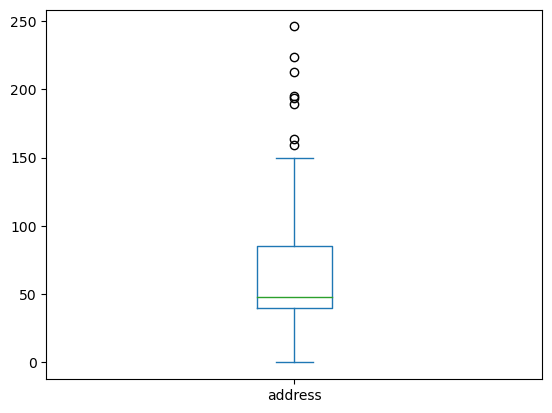

```python
#Now we are try to visualize address in the from of box-plot
df['address'].plot(kind='box')
```

# Let's understand Summary statistic of numerical columns

```python
# This function return that summary statistic of numerical columns
df.describe()
```

|  | is_canceled | lead_time | arrival_date_year | arrival_date_week_number | arrival_date_day_of_month | stays_in_weekend_nights | stays_in_week_nights | adults | children | babies | is_repeated_guest | previous_cancellations | previous_bookings_not_canceled | booking_changes | company | days_in_waiting_list | address | required_car_parking_spaces | total_of_special_requests | reservation_status_date |
| --- | --- | --- | --- | --- | --- | --- | --- | --- | --- | --- | --- | --- | --- | --- | --- | --- | --- | --- | --- | --- |
| count | 217.000000 | 217.000000 | 217.000000 | 217.000000 | 217.000000 | 217.00000 | 217.000000 | 217.000000 | 217.000000 | 217.0 | 217.000000 | 217.000000 | 217.000000 | 217.000000 | 217.000000 | 217.0 | 217.000000 | 217.000000 | 217.000000 | 217 |
| mean | 0.078341 | 40.520737 | 2015.465438 | 38.198157 | 10.824885 | 1.56682 | 4.631336 | 1.410138 | 0.036866 | 0.0 | 0.069124 | 0.009217 | 0.147465 | 1.285714 | 262.105991 | 0.0 | 63.793733 | 0.092166 | 0.198157 | 2016-03-10 17:01:56.129032192 |
| min | 0.000000 | 0.000000 | 2015.000000 | 1.000000 | 1.000000 | 0.00000 | 0.000000 | 1.000000 | 0.000000 | 0.0 | 0.000000 | 0.000000 | 0.000000 | 0.000000 | 9.000000 | 0.0 | 0.000000 | 0.000000 | 0.000000 | 2015-08-09 00:00:00 |
| 25% | 0.000000 | 12.000000 | 2015.000000 | 33.000000 | 6.000000 | 0.00000 | 2.000000 | 1.000000 | 0.000000 | 0.0 | 0.000000 | 0.000000 | 0.000000 | 0.000000 | 281.000000 | 0.0 | 40.000000 | 0.000000 | 0.000000 | 2015-11-15 00:00:00 |
| 50% | 0.000000 | 27.000000 | 2015.000000 | 45.000000 | 9.000000 | 2.00000 | 4.000000 | 1.000000 | 0.000000 | 0.0 | 0.000000 | 0.000000 | 0.000000 | 1.000000 | 281.000000 | 0.0 | 48.000000 | 0.000000 | 0.000000 | 2015-11-15 00:00:00 |
| 75% | 0.000000 | 36.000000 | 2016.000000 | 46.000000 | 13.000000 | 2.00000 | 6.000000 | 2.000000 | 0.000000 | 0.0 | 0.000000 | 0.000000 | 0.000000 | 2.000000 | 281.000000 | 0.0 | 85.000000 | 0.000000 | 0.000000 | 2016-07-10 00:00:00 |
| max | 1.000000 | 364.000000 | 2017.000000 | 53.000000 | 31.000000 | 9.00000 | 21.000000 | 3.000000 | 2.000000 | 0.0 | 1.000000 | 2.000000 | 7.000000 | 6.000000 | 499.000000 | 0.0 | 246.000000 | 1.000000 | 3.000000 | 2017-08-27 00:00:00 |
| std | 0.269329 | 61.748375 | 0.720053 | 12.890292 | 7.582065 | 1.49270 | 3.552846 | 0.520406 | 0.232788 | 0.0 | 0.254252 | 0.135769 | 0.717768 | 1.251454 | 103.602708 | 0.0 | 38.823568 | 0.289929 | 0.546365 | NaN |

```python
#Now we will set conditon below 5000 in the address columns
df1 = df[df['address']<5000]
```

# Data Analysis and Visualization

```python
cancel_per = df['is_canceled'].value_counts#These function return value
```

```python
#with the help of value_counts(normalization=True) function are help we will get entair percentage value counts
cancel_per = df['is_canceled'].value_counts(normalize=True)
print(cancel_per)
```

```
is_canceled
0    0.921659
1    0.078341
Name: proportion, dtype: float64
```

# Observation

This could represent the proportion of canceled items in a dataset, where 0 indicates not canceled and 1 indicates canceled. 2In this case, it suggests that the majority of items are not canceled (around 92.17%), while a small proportion are canceled (about 7.83%)

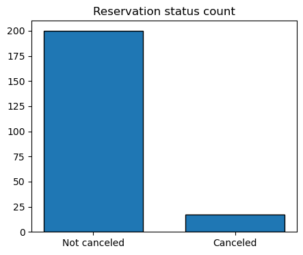

```python
plt.figure(figsize=(5,4))
plt.title('Reservation status count')
plt.bar(['Not canceled','Canceled'],df['is_canceled'].value_counts(),edgecolor='k',width=0.7)
plt.show()
```

# Depending on the hotel we will seen which cancellation rate is more or less

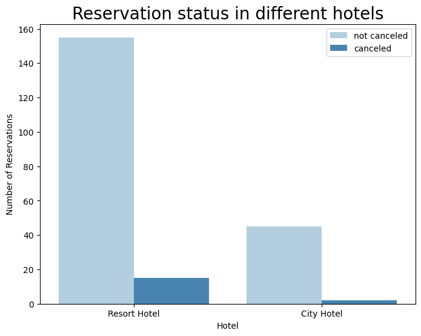

```python
plt.figure(figsize=(8, 6))
axl = sns.countplot(x='hotel', hue='is_canceled', data=df, palette='Blues')
legend_labels, _ = axl.get_legend_handles_labels()
axl.legend(legend_labels, ['not canceled', 'canceled'], bbox_to_anchor=(1, 1))
plt.title('Reservation status in different hotels', size=20)
plt.xlabel('Hotel')
plt.ylabel('Number of Reservations')
plt.show()
```

# Then we will see percentage wise how may percentage are cancelled and not cancelled

```python
#Show first of all we filtter all the resort hotel data and city_hotel data
resort_hotel = df[df['hotel']=='Resort Hotel']
resort_hotel['is_canceled'].value_counts(normalize=True)
```

```
is_canceled
0    0.911765
1    0.088235
Name: proportion, dtype: float64
```

```python
city_hotel = df[df['hotel']=='City Hotel']
city_hotel['is_canceled'].value_counts(normalize=True)
```

```
is_canceled
0    0.957447
1    0.042553
Name: proportion, dtype: float64
```

# Now we will seen should price Causes are affected Resort Hotel and City Hotel is Cancelled

```python
resort_hotel = resort_hotel.groupby('reservation_status_date')[['address']].mean()
city_hotel = city_hotel.groupby('reservation_status_date')[['address']].mean()
```

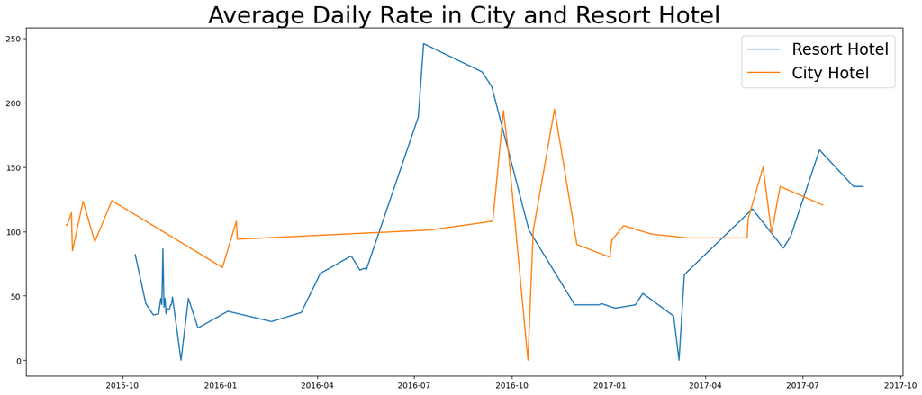

```python
plt.figure(figsize=(20,8))
plt.title('Average Daily Rate in City and Resort Hotel', fontsize = 30)
plt.plot(resort_hotel.index, resort_hotel['address'],label='Resort Hotel')
plt.plot(city_hotel.index, city_hotel['address'],label='City Hotel')
plt.legend(fontsize=20)
plt.show()
```

# Now we will seen through visualization which month are more reservation and also seen which month more cancellation

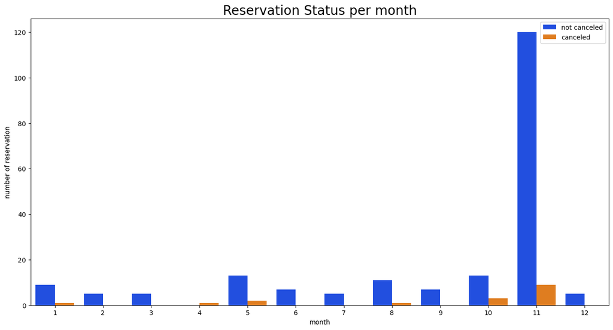

```python
df['month']=df['reservation_status_date'].dt.month
plt.figure(figsize=(16,8))
axl = sns.countplot(x='month',hue='is_canceled',data=df, palette='bright')
legend_label,_ = axl.get_legend_handles_labels()
axl.legend(bbox_to_anchor=(1,1))
plt.title('Reservation Status per month',size=20)
plt.xlabel('month')
plt.ylabel('number of reservation')
plt.legend(['not canceled','canceled'])
plt.show()
```